# Лабораторная работа №2

Структура документа, оглавление и пробелы в LaTeX

Усман Траоре

Российский университет дружбы народов, Москва, Россия

06 декабря 2025

# Цель работы

## Основная цель

- Отработать создание и компиляцию нескольких LaTeX-документов
- Освоить работу с разделами и автоматическим оглавлением
- Исследовать поведение обычных и неразрывных пробелов
- Закрепить навыки работы с абзацами, длинными строками и специальными символами

# Выполнение работы

## Компиляция первого документа

- Открыт и отредактирован файл `exercise-2.1.4.tex`
- Выполнена компиляция с помощью `pdflatex`
- Система успешно создала файл `exercise-2.1.4.pdf` и служебные файлы

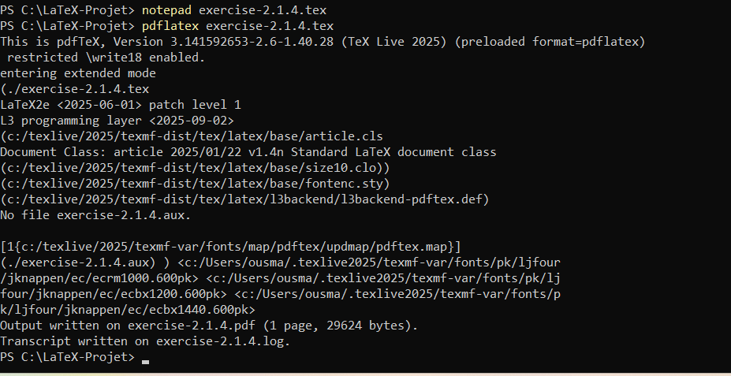

Компиляция exercise-2.1.4.tex

## Результат первого документа

- Документ содержит нумерованные разделы
- Присутствует формула в режиме display math
- Используются перекрёстные ссылки на рисунок и разделы

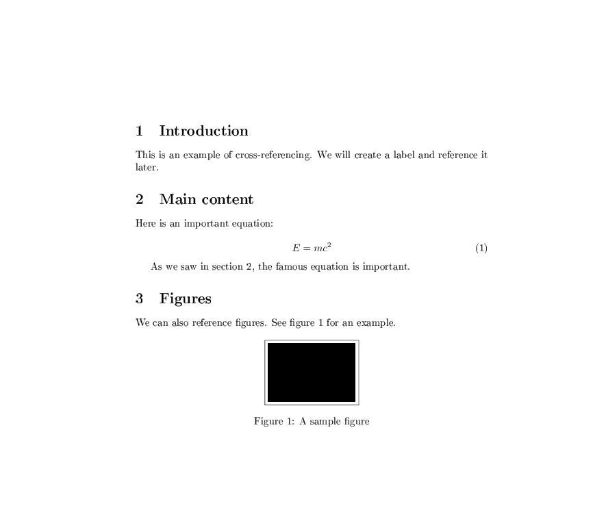

Результат компиляции exercise-2.1.4.pdf

## Компиляция нескольких файлов

- Последовательно скомпилированы `exercise-2.1.4.tex` и `space-comparison.tex`
- Проверено появление соответствующих PDF-файлов в каталоге проекта
- Убедились, что `pdflatex` корректно обрабатывает оба документа

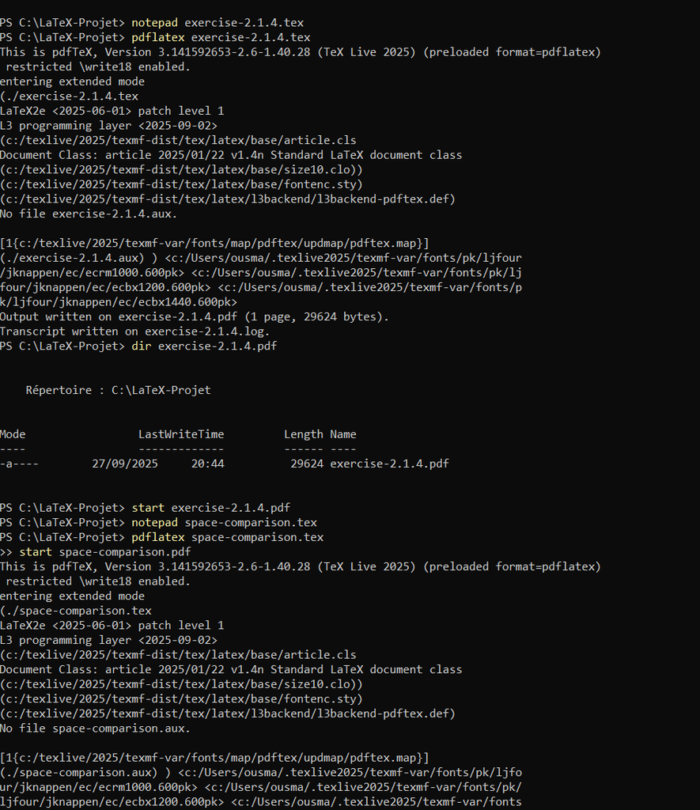

Компиляция нескольких документов и проверка PDF

## Документ с оглавлением

- Создан документ с заголовком, автором и датой
- Добавлена команда `\tableofcontents` для автоматического оглавления
- Проверено совпадение номеров разделов в содержании и основном тексте

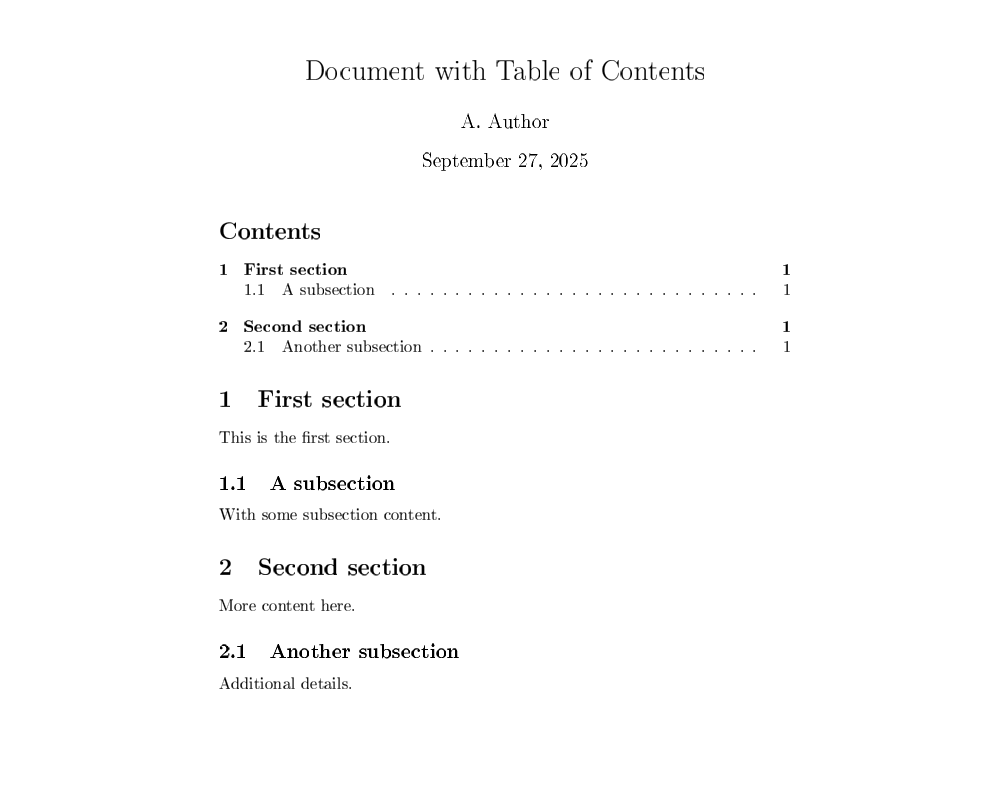

Документ с автоматически сгенерированным оглавлением

## Структура упражнения 2.1.4

- Продемонстрированы несколько уровней секционирования
- Показана работа с абзацами и интервалами между ними
- Проверена устойчивость верстки при длинных строках текста

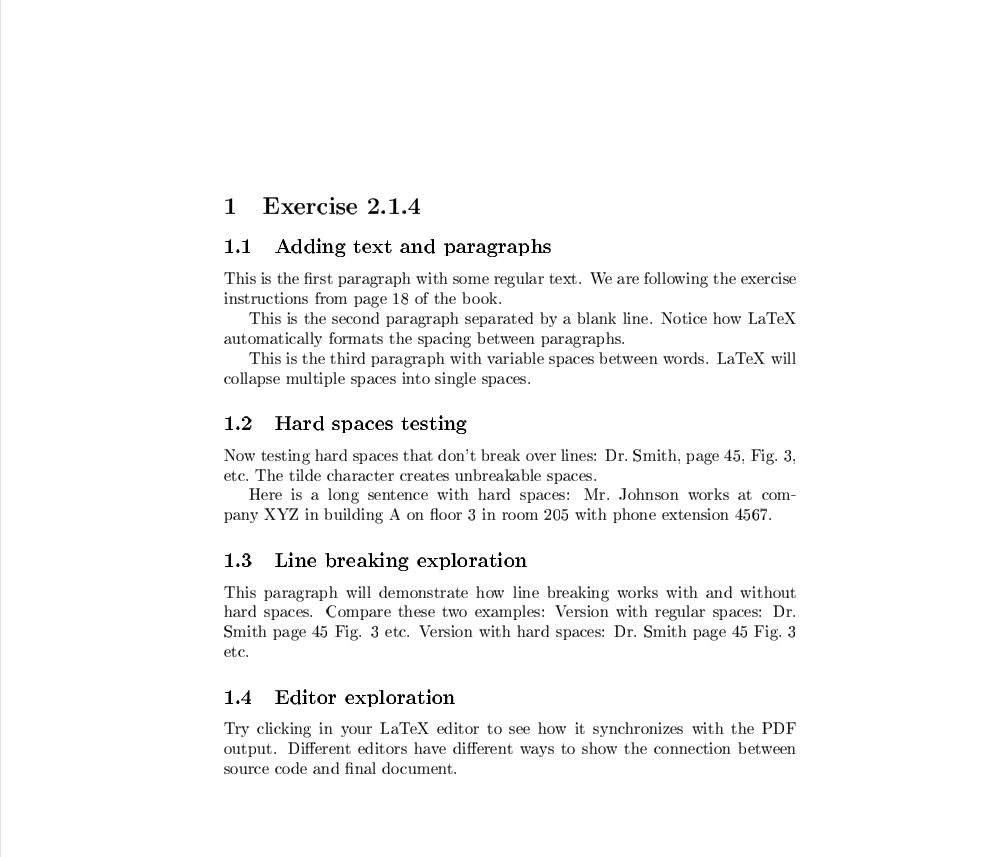

Страницы упражнения 2.1.4

## Итоговый сводный документ

- Создан файл `final-summary.tex`, объединяющий результаты заданий
- При первом проходе LaTeX выдал предупреждения о неразрешённых ссылках
- Повторная компиляция устранила предупреждения и обновила все ссылки

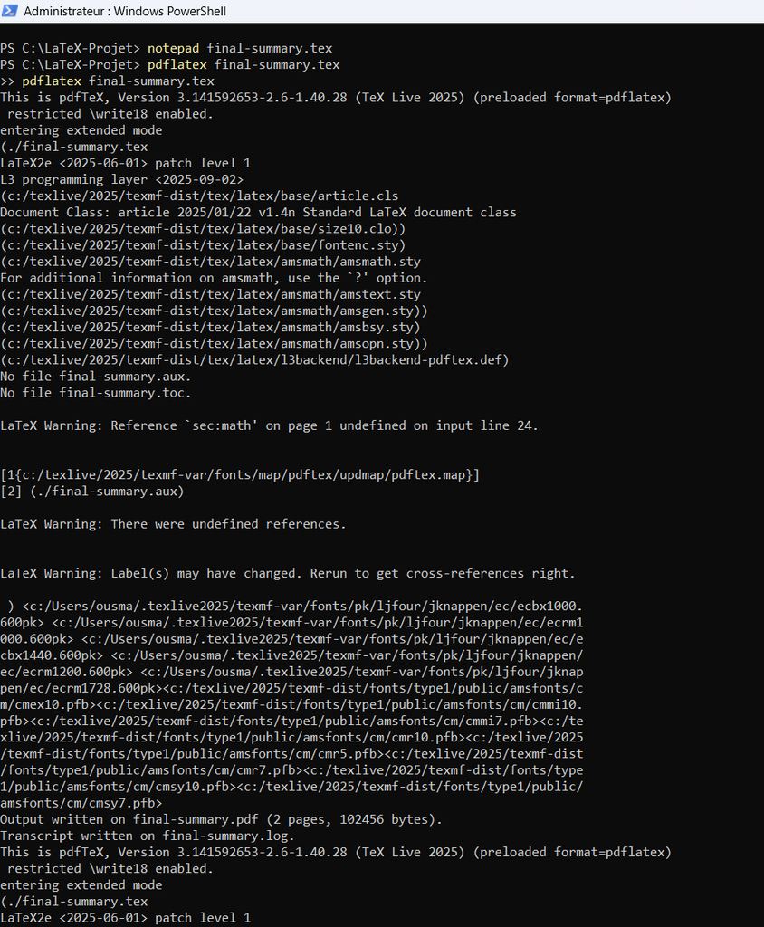

Два прохода компиляции final-summary.tex

## Сравнение типов пробелов

- В документе `space-comparison.pdf` сравниваются:
  - обычные пробелы с возможностью переноса
  - неразрывные пробелы, удерживающие слова на одной строке
- Дополнительно протестированы несколько подряд идущих пробелов и длинные предложения

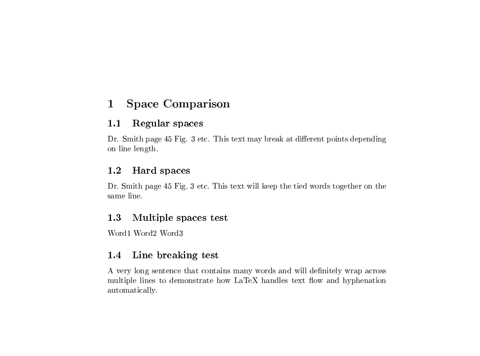

Документ Space Comparison

## Итоговый тестовый документ

- В `mastery-test.tex` собраны все элементы работы:
  - вывод специальных символов
  - разные способы разделения абзацев
  - использование неразрывных пробелов в ссылках и ссылках на объекты
  - тестирование переноса длинных предложений

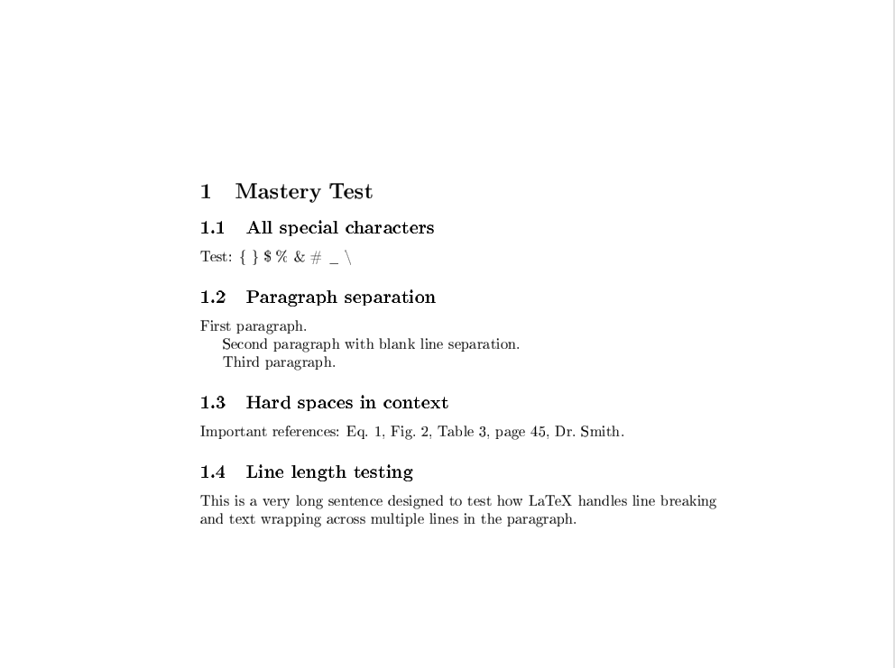

Документ Mastery Test

## Проверка всех PDF-файлов

- Открыты все получившиеся PDF-документы
- Проверено наличие файлов `exercise-2.1.4.pdf`, `space-comparison.pdf`, `mastery-test.pdf` в каталоге
- Размеры и время модификации подтверждают успешную компиляцию каждого документа

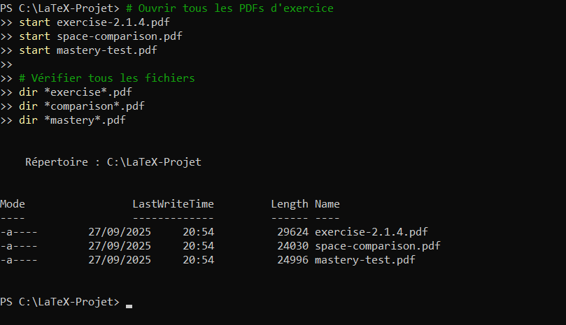

Проверка итоговых PDF-файлов

# Итоги работы

## Выводы

В результате выполнения лабораторной работы:

- освоен процесс компиляции нескольких связанных LaTeX-документов;
- отработано создание структуры документа с разделами и оглавлением;
- исследованы особенности обычных и неразрывных пробелов и их влияние на перенос строк;
- протестирована работа со специальными символами и абзацами в разных контекстах;
- подтверждена корректная работа установленной системы LaTeX и компилятора `pdflatex`.

Все поставленные задачи выполнены, полученные PDF-документы сформированы корректно.